# Gender Disparities in the US Film Industry

Cathy Lee, Dardalie Brooks, and Ha Cao

20 April 2018

Please see our Github repository[^1] for more details on this project.

## Introduction

In the film industry, women are underrepresented: although they account for 50% of moviegoers[^2], they make up a startlingly small percentage of producers, writers, directors[^3], and other significant roles in the films they watch. Our objective is to prove the existence of gender inequality in the US film industry from multiple angles using the `IMDB` database, find out the genres and roles where gender disparity is the most glaring, and whether women are discriminated against beyond representation: a budget gap between male-dominated and female-dominated production teams.

## Scope

We filtered for `movie`s after 1980 to keep our analysis relevant to current events and our sample size manageable. We focused on movies produced by US companies, so we could use the US social climate as a control factor. Including movies made in other countries with different outlooks on gender diversity would make the data difficult to analyze. Furthermore, we filtered for movies with budgets in USD and gross revenues in the US market.

## Data Retrieval from SQL Database

We pulled data frames about movie ID, title, production year, genre, budget, and gross revenue of the movies, and about gender and role of each person in the crew (including actors/actresses).

```r
# set up the environment
library(mdsr)
library(RMySQL)
library(tidyverse)
library(ggpubr)
library(ggthemes)
library(formattable)
theme_set(theme_pubr())
db <- dbConnect_scidb(dbname = "imdb")

# query to get basic information about the movies
# including movie ID, title, production year, genre, budget, and gross revenue in the US
# movie_info.info_type_id is an indexed column
# cast_info.role_id is an indexed column
# we used these indexed columns to make our SQL query more efficient
q1 <- "
SELECT t.id, t.title, t.production_year, mii.info AS genre,
mii2.info AS budget, mii3.info AS gross
FROM title t
JOIN movie_info mii ON mii.movie_id = t.id
JOIN movie_info mii2 ON mii2.movie_id = t.id
JOIN movie_info mii3 ON mii3.movie_id = t.id
JOIN movie_companies mc ON mc.movie_id = t.id
JOIN company_name cn ON cn.id = mc.company_id
WHERE t.kind_id = 1
 AND mii.info_type_id = 3
 AND mii2.info_type_id = 105
 AND mii2.info LIKE '$%'
 AND mii3.info_type_id = 107
 AND cn.country_code = '[us]'
 AND production_year > 1980
 AND mii3.info LIKE '%(USA)'
ORDER BY mii2.info desc;
"
movies_all_info <- db %>%
  dbGetQuery(q1)

# query to get information about crew personnel of the movies
q2 <- "
SELECT ci.movie_id, ci.person_role_id AS char_id,
n.gender, rt.role
FROM cast_info ci
JOIN movie_info mii ON mii.movie_id = ci.movie_id
JOIN title t ON mii.movie_id = t.id
JOIN movie_info mii2 ON mii2.movie_id = t.id
JOIN name n ON n.id = ci.person_id
JOIN role_type rt ON rt.id = ci.role_id
JOIN movie_companies mc ON mc.movie_id = t.id
JOIN company_name cn ON cn.id = mc.company_id
WHERE mii.info_type_id = 105
 AND mii.info LIKE '$%'
 AND mii2.info_type_id = 107
 AND cn.country_code = '[us]'
 AND t.production_year > 1980
 AND mii2.info LIKE '%(USA)'
 AND t.kind_id = 1
ORDER BY mii.info DESC;
"
crew_info <- db %>%
  dbGetQuery(q2)

# query to get movies made by US companies only
# get gender and budget information for each movie
# and info about production team (director, producer, writer)
sql <- "
SELECT t.title, mi.info AS budget, n.gender, t.production_year
FROM cast_info ci
JOIN name n ON n.id = ci.person_id
JOIN movie_info mi ON mi.movie_id = ci.movie_id
JOIN movie_info mi2 ON mi2.movie_id = mi.movie_id
JOIN title t ON t.id = mi.movie_id
JOIN movie_companies mc ON mc.movie_id = t.id
JOIN company_name cn ON cn.id = mc.company_id
WHERE mi.info_type_id = 105
  AND mi.info LIKE '$%'
  AND ci.role_id IN (3,4,5)
  AND mi2.info_type_id = 107
  AND mi2.info LIKE '%(USA)'
  AND cn.country_code = '[us]'
  AND t.production_year > 1980
  AND t.kind_id = 1
ORDER BY t.title;
"
budget_by_gender <- db %>%
  dbGetQuery(sql)
```

## Data Analysis

### Gender Representation by Role in the Crew

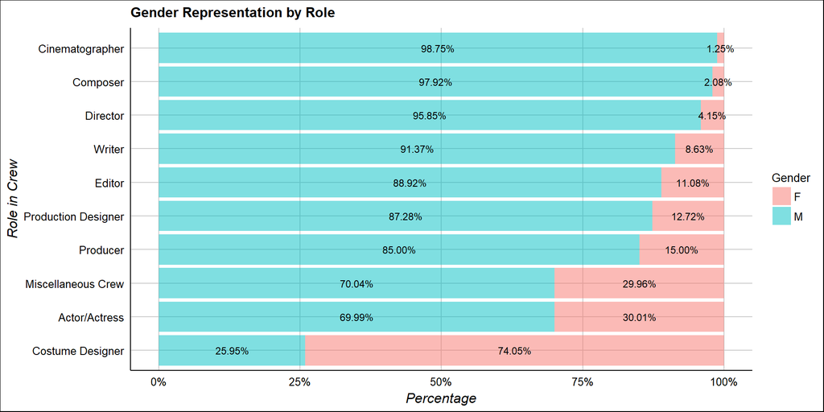

```r
# throughout the data wrangling process,
# we dropped NA values in gender
# a table that has a total number of people as a column
# in order to join with crew_short later
crew_total <- crew_info %>%
  mutate(role_in_movie = ifelse(role %in% c("actor", "actress"), "actor/actress", role)) %>%
  group_by(movie_id, role_in_movie) %>%
  drop_na(gender) %>%
  summarize(total = n()) %>%
  group_by(role_in_movie) %>%
  summarize(total = sum(total))

# specific info about gender distribution within each role of the crew for each movie
crew_short <- crew_info %>%
  mutate(role_in_movie = ifelse(role %in% c("actor", "actress"), "actor/actress", role)) %>%
  group_by(movie_id, role_in_movie, gender) %>%
  summarize(num = n()) %>%
  drop_na(gender) %>%
  group_by(role_in_movie, gender) %>%
  summarize(total_by_gender = sum(num)) %>%
  inner_join(crew_total, by = "role_in_movie") %>%
  mutate(prop = total_by_gender/total) %>%
  group_by(role_in_movie) %>%
  mutate(prop_female = first(prop))

# create a stacked bar chart of gender ratio for different roles in movies
ggplot(data = crew_short, aes(x = reorder(role_in_movie, -prop_female), y = prop, fill = gender)) +
  geom_bar(stat = "identity", position = "fill", alpha = 0.5) +
  scale_y_continuous(name = "Percentage", labels = scales::percent) +
  theme_gdocs() +
  labs(title = "Gender Representation by Role") +
  theme(plot.title = element_text(size = 12),
        legend.title = element_text(size = 10)) +
  scale_fill_manual(values = c("#f8766d", "#00bfc4"), name = "Gender", breaks = c("f", "m"), labels = c("F", "M")) +
  scale_x_discrete(name = "Role in Crew", labels = c("cinematographer" = "Cinematographer", "composer" = "Composer",
                              "director" = "Director", "writer" = "Writer",
                              "editor" = "Editor", "production designer" = "Production Designer",
                              "producer" = "Producer", "miscellaneous crew" = "Miscellaneous Crew",
                              "actor/actress" = "Actor/Actress", "costume designer" = "Costume Designer")) +
  geom_text(aes(label = percent(prop), y = prop), size = 3, position = position_stack(vjust = 0.5)) +
  coord_flip()
```

Almost all employment fields are male-dominated except costume designing ($\approx \dfrac{3}{4}$ female). Although costume designing plays a pivotal role in movie production, its weekly base salary is $2,789.73, lower than that of production designers, a similar field that is male-dominated, boasting a weekly base salary of $3,754.47[^4]. Sadly, the only field that is female-dominated is not as well-paid as male-dominated fields.

Over the 36-year period, women accounted for 4% of directors, arguably the most powerful position in a film crew. This statistic was 8% in 2017, indicating some positive change regarding gender diversity. However, cinematography is the most heavily male-dominated field - women made up only 1.3% of cinematographers in the US film industry. This percentage, unlike that of directors, has barely changed - it only rose slightly to 2% in 2017[^5].

Some contend that gender discrimination in the film industry is non-existent - making movies takes a toll on personal relationships, and filming might be located far from one’s residence. Women are usually the primary care-givers of the family[^6], and cannot afford to be away from home for prolonged periods, thereby not applying for jobs in the film industry as often as men. However, this is a misconception: interviews conducted by the US Equal Employment Opportunity Commission (EEOC) uncovered hiring discrimination faced by women who applied to work in the film industry, but were rejected because the crew “[didn’t] like working with women”, though the women applying were sufficiently qualified[^7]. Therefore the issue is not a deficiency of women applying for jobs but rather discrimination in the hiring process.

Additionally, some may argue that men are more capable than women in the film industry, so understandably, they are underreprensented. However, that argument cannot explain why there are fewer women starred in movies than men. Women make up ~50% of our population and movies depict reality, so 50% of the cast should have been women instead of 30% as shown in our graph.

### Gender Representation by Genre

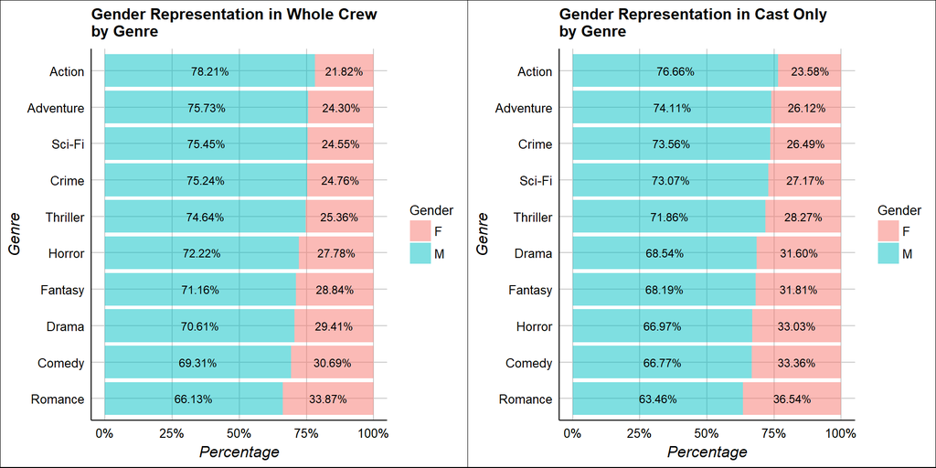

```r
# codes for the whole crew in general
# a table that has a total number of people as a column
# in order to join with crew_general later
crew_total_2 <- crew_info %>%
  group_by(movie_id, gender) %>%
  summarize(total = n()) %>%
  drop_na(gender) %>%
  group_by(movie_id) %>%
  summarize(total = sum(total))

# general info about gender distribution (all roles together) for each movie
crew_general <- crew_info %>%
  group_by(movie_id, gender) %>%
  summarize(num = n()) %>%
  drop_na(gender) %>%
  inner_join(crew_total_2, by = "movie_id") %>%
  mutate(prop = num/total)

# codes for actors/actresses specifically
# a table that has a total number of people as a column
# in order to join with crew_general_acting later
crew_total_acting <- crew_info %>%
  filter(role %in% c("actor", "actress")) %>%
  group_by(movie_id, gender) %>%
  summarize(total = n()) %>%
  drop_na(gender) %>%
  group_by(movie_id) %>%
  summarize(total = sum(total))

# general info about gender distribution of actors/actresses for each movie
crew_general_acting <- crew_info %>%
  filter(role %in% c("actor", "actress")) %>%
  group_by(movie_id, gender) %>%
  summarize(num = n()) %>%
  drop_na(gender) %>%
  inner_join(crew_total_acting, by = "movie_id") %>%
  mutate(prop = num/total)

# top 10 most popular genres (most movies listed in that genre)
top_genres <- movies_all_info %>%
  group_by(genre) %>%
  summarize(num_movies = n()) %>%
  arrange(desc(num_movies)) %>%
  head(10)

# filter out top 10 genres
top_genres_info <- movies_all_info %>%
  filter(genre %in% c("Drama", "Comedy", "Thriller", "Action", "Adventure", "Crime", "Romance", "Sci-Fi", "Fantasy", "Horror")) %>%
  group_by(genre, id) %>%
  summarize(title = first(title),
            production_year = first(production_year),
            budget = first(budget),
            gross = first(gross))

# parse $ budget and gross into real numbers to calculate
top_genres_info <- top_genres_info %>%
  mutate(real_budget = parse_number(budget),
         real_gross = parse_number(gross))

# join crew_general with top_genres_info to get the gender distribution of the whole crew for each movie within each genre
gender_by_genre_crew <- top_genres_info %>%
  inner_join(crew_general, by = c("id" = "movie_id")) %>%
  group_by(genre, gender) %>%
  summarize(budget = mean(real_budget),
            gross_revenue = mean(real_gross),
            prop = mean(prop)) %>%
  group_by(genre) %>%
  mutate(prop_female = first(prop))

gender_by_genre_acting <- top_genres_info %>%
  inner_join(crew_general_acting, by = c("id" = "movie_id")) %>%
  group_by(genre, gender) %>%
  summarize(budget = mean(real_budget),
            gross_revenue = mean(real_gross),
            prop = mean(prop)) %>%
  group_by(genre) %>%
  mutate(prop_female = first(prop))

# graphs about gender distribution by genre
# create a stacked bar chart for different roles in movies
gender_crew_plot <- ggplot(data = gender_by_genre_crew, aes(x = reorder(genre, -prop_female), y = prop, fill = gender)) +
  geom_bar(stat = "identity", position = "fill", alpha = 0.5) +
  scale_x_discrete(name = "Genre") +
  scale_y_continuous(name = "Percentage", labels = scales::percent) +
  theme_gdocs() +
  labs(title = "Gender Representation in Whole Crew \nby Genre") +
  theme(plot.title = element_text(size = 12),
        legend.title = element_text(size = 10)) +
  scale_fill_manual(values = c("#f8766d", "#00bfc4"), name = "Gender", breaks = c("f", "m"), labels = c("F", "M")) +
  geom_text(aes(label = percent(prop), y = prop), size = 3, position = position_stack(vjust = 0.5)) +
  coord_flip()

gender_acting_plot <- ggplot(data = gender_by_genre_acting, aes(x = reorder(genre, -prop_female), y = prop, fill = gender)) +
  geom_bar(stat = "identity", position = "fill", alpha = 0.5) +
  scale_x_discrete(name = "Genre") +
  scale_y_continuous(name = "Percentage", labels = scales::percent) +
  theme_gdocs() +
  labs(title = "Gender Representation in Cast Only \nby Genre") +
  theme(plot.title = element_text(size = 12),
        legend.title = element_text(size = 10)) +
  scale_fill_manual(values = c("#f8766d", "#00bfc4"), name = "Gender", breaks = c("f", "m"), labels = c("F", "M")) +
  geom_text(aes(label = percent(prop), y = prop), size = 3, position = position_stack(vjust = 0.5)) +
  coord_flip()

figure <- ggarrange(gender_crew_plot, gender_acting_plot,
                    ncol = 2, nrow = 1)
figure
```

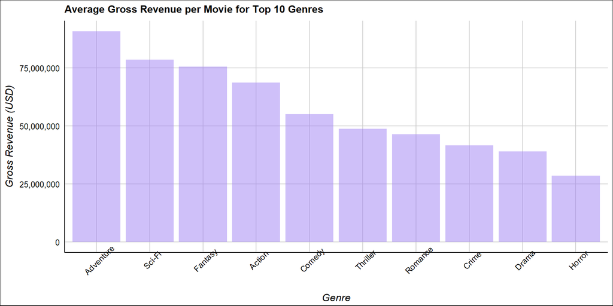

```r
gross_by_genre <- gender_by_genre_crew %>%
  group_by(genre) %>%
  summarize(gross_revenue = mean(gross_revenue))

gross_plot <- ggplot(data = gross_by_genre, aes(x = reorder(genre, -gross_revenue), y = gross_revenue)) +
  geom_bar(stat = "identity", alpha = 0.5, fill = "#a081f4") +
  theme_gdocs() +
  theme(axis.text.x = element_text(angle = 45)) +
  scale_x_discrete(name = "Genre") +
  scale_y_continuous(name = "Gross Revenue (USD)", labels = scales::comma) +
  labs(title = "Average Gross Revenue per Movie for Top 10 Genres") +
  theme(plot.title = element_text(size = 12))
gross_plot
```

We picked the top 10 genres with the most movies and analyzed the average gross revenue per movie in these genres. We wanted to see which genres made more movies, which means more opportunities to be part of the crew/cast, and which genres grossed most money. Together with our analysis of gender representation by genre, we can recommend to women genres where more opportunities are available, revenues are higher, and two genders are more equally represented. Among the genres that we analyzed, Comedy seems to be the best option for women, as it is one of the two genres with the highest female proportion (30.69%-33.36%), in the top 10 most-movie genres, and in the top 5 highest-average-grossing genres. However, dishearteningly, there might be more women in comedies because they are often at the root of sexist jokes[^8]. Romance is also a viable option, but its movies grossed less compared to Comedy by ~$9m per movie. Overall, the lack of women in all genres could be attributed to male-led movies being considered universally relatable and more complex, while female-led movies are othered and trivialised[^9].

### Change of Female Representation in the Whole Crew by Genre from 1981-2017

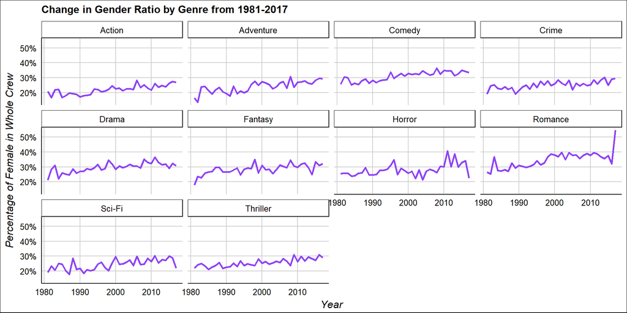

```r
# all top 10 genres_crew ratios_over time
gender_crew_time_top10 <- top_genres_info %>%
  inner_join(crew_general, by = c("id" = "movie_id")) %>%
  group_by(genre, gender, production_year) %>%
  summarize(prop_female = mean(prop))
time_f_top10 <- subset(gender_crew_time_top10, gender_crew_time_top10$gender == "f")

# plot All genres
timeplot <- ggplot(data = time_f_top10,
                      aes(x = production_year, y = prop_female)) +
  geom_line(col = "#8f42f4", size = 1) +
  scale_x_continuous(name = "Year")+
  scale_y_continuous(name= "Percentage of Female in Whole Crew", labels = scales::percent)+
  theme_gdocs() +
  facet_wrap(~genre) +
  labs(title = "Change in Gender Ratio by Genre from 1981-2017") +
  theme(plot.title = element_text(size = 12))

timeplot
```

```r
# gender ratio's overall change over the last 36 years for each genre
top_genre_percent_change <- time_f_top10 %>%
  filter(production_year %in% c("1981", "2017")) %>%
  group_by(genre) %>%
  summarize(prop_change = last(prop_female) - first(prop_female)) %>%
  arrange(desc(prop_change))

top_genre_percent_change
```

```
## # A tibble: 10 x 2
##    genre     prop_change
##    <chr>           <dbl>
##  1 Romance        0.282
##  2 Fantasy        0.141
##  3 Adventure      0.131
##  4 Crime          0.101
##  5 Drama          0.0973
##  6 Comedy         0.0781
##  7 Thriller       0.0697
##  8 Action         0.0617
##  9 Sci-Fi         0.0287
## 10 Horror        -0.0309
```

```r
# the mean change of gender ratio across all genres
mean_change <- mean(top_genre_percent_change$prop_change)
mean_change
```

```
## [1] 0.09592716
```

We observed how the percentage of female crew members changed from 1981-2017 in the top 10 most-movie genres. Romance has the biggest change in female proportion (28.2%) over the last 36 years, with Fantasy coming in second. The relatively high female participation in Romance can be attributed to the prevalence of heterosexuality in mainstream media, pairing a man and a woman - in 2015, only 17.5% of films contained LGBT characters, and 65% of those characters were gay men, compared to 10% lesbians. Additionally, most genres seemed to start around 20% and over the last 36 years, the female proportion has increased to roughly 30%, which means it took ~35 years to get a 10% (absolute) increase. Therefore, it would take ~70 more years at this rate to reach equal gender representation.

### Budget Gap between Production Teams that are Different in Majority Gender

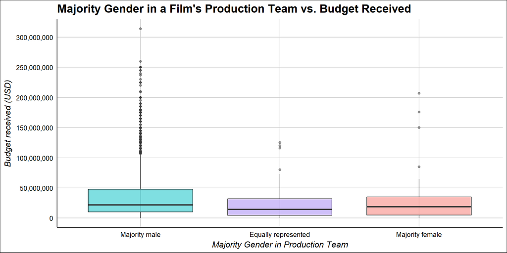

```r
# calculate the gender demographics on the production team of each movie
# calculate whether a movie's production team is female or male dominated
budget_majority_gender <- budget_by_gender %>%
  mutate(parsed_budget = parse_number(budget)) %>%
  group_by(title) %>%
  drop_na(gender) %>%
  summarize(production_year = first(production_year),
            num_male = sum(gender == 'm'),
            num_female = sum(gender == 'f'),
            parsed_budget = mean(parsed_budget)) %>%
  mutate(dominant_gender = ifelse(num_male >= num_female, ifelse(num_male > num_female, "majority_male", "equal"), "majority_female")) %>%
  arrange(desc(parsed_budget))

# plot the boxplot
budget_gender_plot <- budget_majority_gender %>%
  ggplot(aes(x = as.factor(dominant_gender), y = parsed_budget, fill = dominant_gender)) +
  geom_boxplot(alpha = 0.5) +
  theme_gdocs() +
  ggtitle("Majority Gender in a Film's Production Team vs. Budget Received") +
  scale_x_discrete(name = "Majority Gender in Production Team",
                   limits = c("majority_male", "equal", "majority_female"),
                   labels = c("Majority male", "Equally represented", "Majority female")) +
  scale_fill_manual(values = c( "#a081f4","#f8766d","#00bfc4")) +
  scale_y_continuous(name = "Budget received (USD)",
                     labels = scales::comma,
                     breaks = seq(0, 300000000, 50000000)) +
  guides(fill = FALSE)
budget_gender_plot
```

We investigated the relationship between the majority gender in a film’s production team (comprising writers, producers, and directors) and the budget that film received. Interestingly, female-dominated teams had a lower upper and lower quartiles than male-dominated teams. Male-dominated teams also have far more outliers compared to female-dominated and equally represented teams, indicating that there were many movies with exorbitant budgets given to male-dominated teams. Although the median is roughly the same for male and female-dominated teams, the fact remains that the highest budgets are largely given to male-dominated teams.

Upon further research, we found that film industry decision-makers perceive that female directors make films tailored for only a subset of the market, while male directors are expected to make films that are more generalised and wide-reaching. They also doubt the competence of female directors, and wrongly assume a scarcity of female directors (when in fact they simply ignore them)[^10]. This could account for why men are more likely to be hired over women for production teams.

```r
# run a regression model to test whether the difference in budget between male and female-dominated production team is significant
budget_majority_gender$dominant_gender <- as.factor(budget_majority_gender$dominant_gender)
budget_majority_gender$dominant_gender <- relevel(budget_majority_gender$dominant_gender, ref = "majority_male")
budget_model <- lm(data = budget_majority_gender, parsed_budget ~ dominant_gender + production_year)
summary(budget_model)
```

```
##
## Call:
## lm(formula = parsed_budget ~ dominant_gender + production_year,
##     data = budget_majority_gender)
##
## Residuals:
##       Min        1Q    Median        3Q       Max
## -70624414 -19955787  -5490101  11560551 254294213
##
## Coefficients:
##                                  Estimate Std. Error t value Pr(>|t|)
## (Intercept)                    -3.650e+09  1.297e+08 -28.132  < 2e-16 ***
## dominant_genderequal           -1.304e+07  4.862e+06  -2.682  0.00736 **
## dominant_gendermajority_female -1.412e+07  4.706e+06  -3.000  0.00272 **
## production_year                 1.845e+06  6.494e+04  28.409  < 2e-16 ***
## ---
## Signif. codes:  0 '***' 0.001 '**' 0.01 '*' 0.05 '.' 0.1 ' ' 1
##
## Residual standard error: 36040000 on 3025 degrees of freedom
## Multiple R-squared:  0.2123, Adjusted R-squared:  0.2115
## F-statistic: 271.8 on 3 and 3025 DF,  p-value: < 2.2e-16
```

```r
confint(budget_model, level = .95) # obtain 95% CIs for all coefficients
```

```
##                                      2.5 %      97.5 %
## (Intercept)                    -3904267560 -3395490350
## dominant_genderequal             -22571885    -3506848
## dominant_gendermajority_female   -23348725    -4892295
## production_year                    1717449     1972093
```

We ran a multiple regression model to find the relationship between the majority gender of the production team and the budget a film receives. The 95% confidence interval of the coefficient of `majority_female` = [-23348725, -4892295], meaning we are 95% confident that female-dominated production teams have from 4.89m to 23.35m less in budget than male-dominated teams per movie.

The coefficient -14.12m indicates that female-dominated production teams are predicted to have on an average budget of $14.12m less than male-dominated production teams per movie, adjusted for production year. Because p-value is 0.003 (< 0.05), there is sufficient evidence that this budget gap is statistically significant.

[^1]: Our [Github Repository](https://github.com/cathyleee/sds192-mp4)
[^2]: Statistic from [MPAA 2017](https://www.mpaa.org/wp-content/uploads/2018/04/MPAA-THEME-Report-2017_Final.pdf)
[^3]: Women comprised only 24% of protagonists in 2017 according to the [Center for the Study of Women in Television and Film](https://womenandhollywood.com/resources/statistics/), and were in the extreme minority where significant roles in production were concerned.
[^4]: The salaries of the Art Directors Guild, whose members are 73% male, and that of the Costume Designers Guild, whose members are almost 80% female, were compared in a [Variety article](http://variety.com/2016/biz/news/art-director-costumes-groups-gender-inequality-1201905400/).
[^5]: Retrieved from a study conducted by the [Center for the Study of Women in Television and Film](https://womenintvfilm.sdsu.edu/wp-content/uploads/2018/01/2017_Celluloid_Ceiling_Report.pdf)
[^6]: Women are found by the [Pew Research Centre](http://www.pewresearch.org/fact-tank/2015/10/01/women-more-than-men-adjust-their-careers-for-family-life/) to be more likely than men to adjust their careers for family life.
[^7]: From excerpts of interviews on gender discrimination in the film industry conducted by the [EEOC](http://www.scpr.org/programs/the-frame/2017/02/16/55132/gender-discrimination-in-hollywood-is-real/).
[^8]: Comedies are much less likely to be palatable for male audiences if humour is seen from a woman’s perspective. Retrieved from [IndieWire](http://www.indiewire.com/2011/04/the-misogyny-machine-that-rules-hollywood-comedies-212615/).
[^9]: We are subconsciously more critical of female-led movies, and more likely to see women as two-dimensional. Retrieved from [the Guardian](https://www.theguardian.com/news/2018/mar/06/the-male-glance-how-we-fail-to-take-womens-stories-seriously).
[^10]: Obstacles female directors face in the film industry by the [Female Filmmakers Initiative](http://www.sundance.org/pdf/artist-programs/wfi/phase-iii-research---female-filmmakers-initiative.pdf).